# Capsule 4 - Comparer sur une validation commune

MQT-2101 - Analyse et modélisation des données

## Pourquoi ça compte

Le calendrier fait-il mieux que reprendre la dernière année?

Un bon ajustement ne garantit pas une prévision utile des prochains mois.

## Objectifs de la capsule

- Construire le calendrier futur.
- Comparer les mêmes cibles à une seule origine.
- Interpréter ME, MAE et RMSE en dollars.

## Connaître le calendrier, pas les ventes

- Les mois de 2025 sont connus fin 2024.
- L’indice continue de 61 à 72.
- Les ventes futures ne servent pas à prévoir.
- Le budget cible ne sert pas de prédicteur.

## Quatre candidats annoncés

Tendance et saison

deux modèles séparés

Calendrier

tendance et mois ensemble

Naïf saisonnier

reprendre les douze mois de 2024

## Des informations identiques

Une seule origine à la fin de 2024. Douze horizons et douze cibles communs. Paramètres estimés sur 2020 à 2024.

Mettre à jour une prévision avec une vente de 2025 répondrait à un autre protocole.

## Les erreurs sur la validation

ME : erreur moyenne signée. MAE : erreur absolue moyenne. RMSE : racine de l’erreur quadratique moyenne.

| Méthode | ME ($ CA) | MAE ($ CA) | RMSE ($ CA) |
| --- | --- | --- | --- |
| Calendrier | -3 538 | 9 891 | 11 280 |
| Tendance | -4 347 | 17 064 | 20 292 |
| Naïf saisonnier | 29 067 | 29 067 | 30 170 |
| Saison | 100 302 | 100 302 | 100 872 |

## Les trajectoires complètent le classement

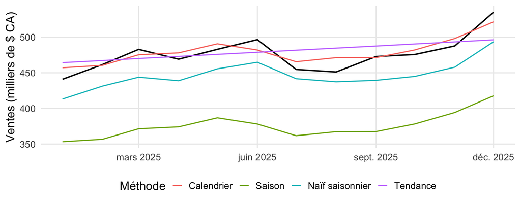

## Choisir provisoirement

- Le modèle combiné a ici la plus petite MAE.
- Le modèle saisonnier seul ne décrit pas la croissance.
- La validation sert au choix, sans test final indépendant.
- Le classement doit être réévalué à de nouvelles origines.

## Deux façons de prolonger le lissage

- Holt-Winters combine niveau, tendance et saisonnalité.
- ETS permet de choisir une structure d’erreur, de tendance et de saisonnalité.
- Dans l’exemple accompagné, comparez leurs erreurs sur les mêmes mois de 2025.

Les quatre candidats de l’activité 8.4 restent ceux du tableau précédent.

## À retenir

Comparer

mêmes dates et informations

Mesurer

erreurs en dollars

Choisir

un résultat limité à ce protocole

## Production autonome 8.4

Construisez le calendrier de 2025 avec les indices 61 à 72. Émettez les prévisions des trois modèles et du naïf saisonnier à l’origine de fin 2024. Calculez ME, MAE et RMSE en dollars, tracez les trajectoires et justifiez un choix provisoire.

Cette production se réalise une seule fois dans le rapport guidé.

### Auto-vérification

- Les quatre candidats utilisent les mêmes douze cibles et informations disponibles.
- Je n’ai utilisé ni ventes futures ni budget cible comme prédicteur.
- Mon choix repose sur les erreurs de validation et reste provisoire.